# scRNAseq Interstitial cells : cluster attribution

Marion Hardy

2024-02-18

# Introduction

**This assumes you have run the** “interstitial_report1.Rmd” document and generated the seurat_f and seurat_r objects.

Data from our collaborator Panagiotis rds file for a SingleCellExperiment object containing the single cell data for **the interstitial cells** of *Hydra Vulgaris* during multiples stages of regeneration after bisection:

https://www.dropbox.com/scl/fi/dg76sigjnj5u6qr06xk79/sce_interstitial_Juliano.rds?rlkey=f0y3lqt0wdcwq652zisnrpf9t&dl=0

BUT they mapped it to *Hydra Magnipapillata (105)* “Drop-seq reads from 15 libraries generated for Hydra vulgaris strain AEP were mapped to the 2.0 genome assembly of closely related Hydra vulgaris strain 105 (available at https://research.nhgri.nih.gov/hydra/) and processed using the Hydra 2.0 gene models. Strain Hydra vulgaris 105 was formerly referred to as Hydra magnipapillata 105.”

The coldata of the object contain cell annotation including

- quality metrics: nFeature nCount (not MT percentage interestingly)
- batch info: either 2869 (3162 barcodes), 3113 (10352 barcodes), 3271 (13279 barcodes), 3357 (3875 barcodes)
- originating experiments (head or foot regeneration)
- experimental time points
- pseudo-axis assignment (vals.axis ranging from 0-1, increasing in the foot-tentacle direction)
- mitotic and apoptotic signatures indices from 0 to 1

The rowdata contains gene annotation, using Entrez-gene identifiers. I have also noticed that in the sce objects there’s

- PCA, tSNE and UMAP coordinates for reduced dimensions + corrected for batch values
- assay metafeatures hold gene_id, product, gene, is.rib.prot.gene (T/F), HypoMarkers (T/F), ccyle (T/F), apopt (T/F) etc

I converted the sce objects 6.6gb into a seurat object 2.2 gb and checked that all cited parameters could be found in it.

# Data loading

Which dataset set should I use? Batch regressed looks weird but might be interesting depending on how timepoints end up clustering…

# Subsetting by head/foot and timepoint for both regressed and unregressed

## Not batch regressed

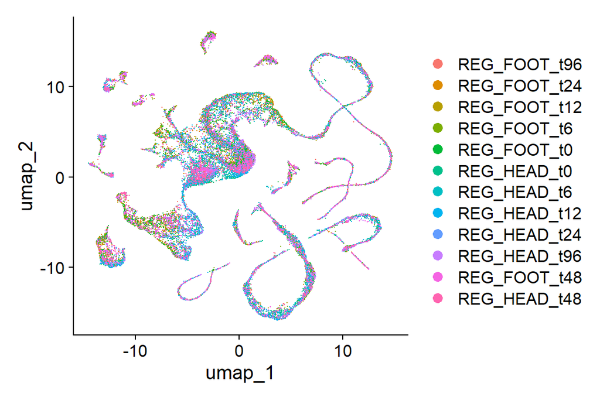

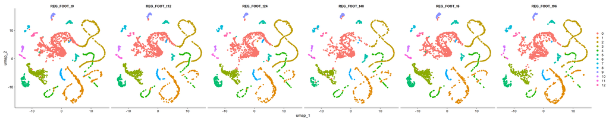

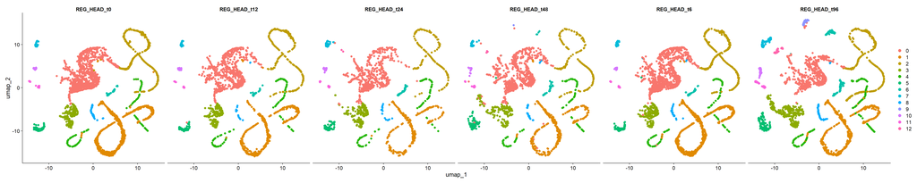

We don’t really see time-dependent clustering here.

## Batch regressed

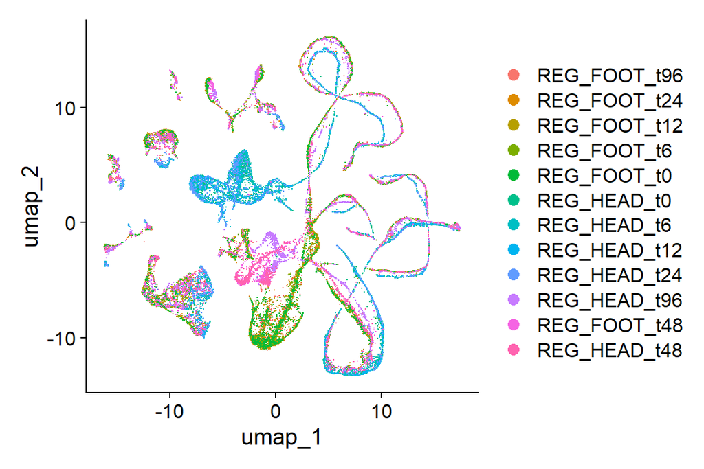

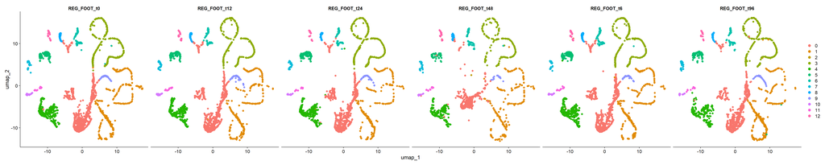

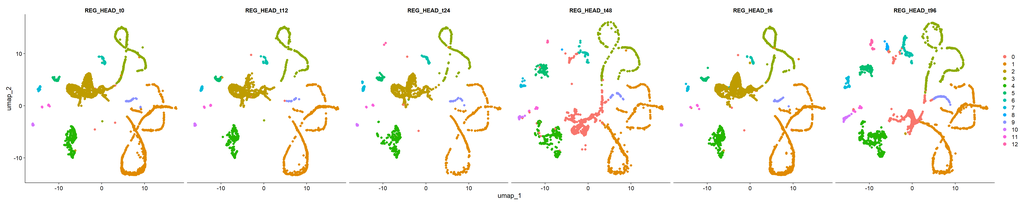

There’s much more time dependent-clustering happening here. I will move forward with the non regressed data unless told otherwise because the clustering at higher resolutions do not indicate that later timepoints have their own clusters so regressing the batch might have induced artefact?

# Cluster attribution

## UMAP at 0.025 resolution

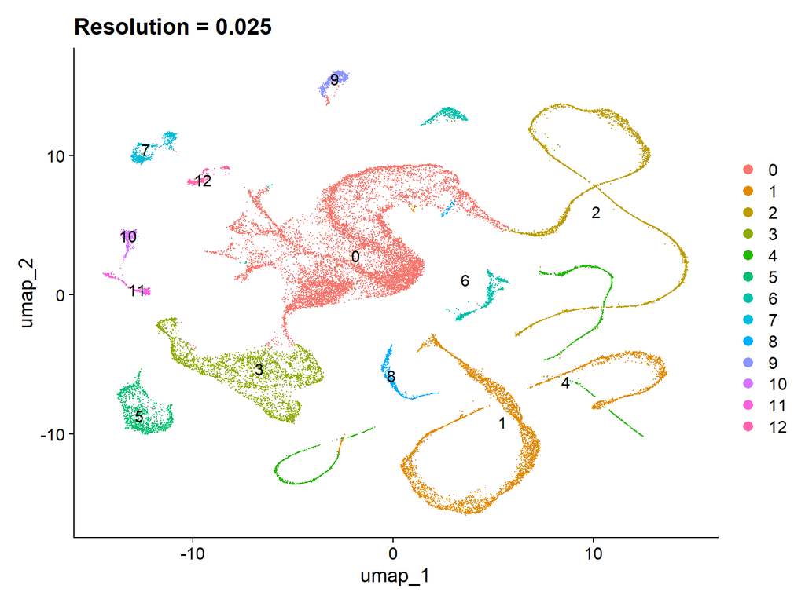

## Finding markers per clusters

### Markers that seem specific to cluster identity.

```
##           X p_val avg_diff pct.1 pct.2 p_val_adj cluster      gene
## 1      TYN1     0 4.119999 0.930 0.221         0       0      TYN1
## 2 100202274     0 3.956395 0.972 0.264         0       0 100202274
## 3     ANO39     0 3.428284 0.861 0.212         0       0     ANO39
## 4 100204143     0 3.187916 0.907 0.200         0       0 100204143
## 5 100205951     0 3.001540 0.674 0.184         0       0 100205951
## 6 100204347     0 2.919926 0.482 0.151         0       0 100204347
```

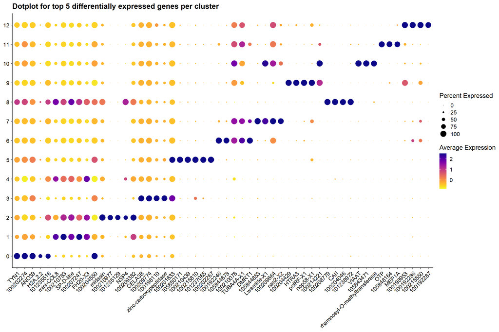

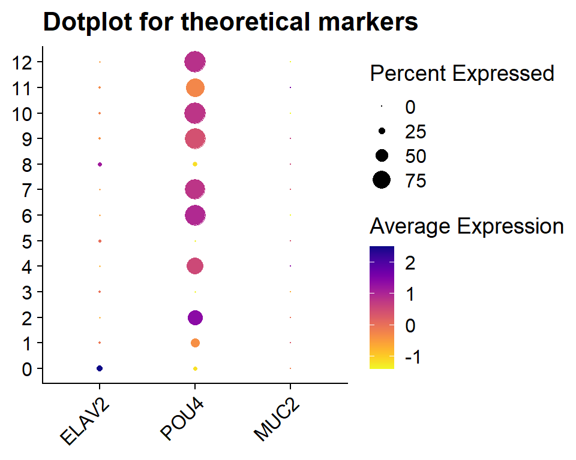

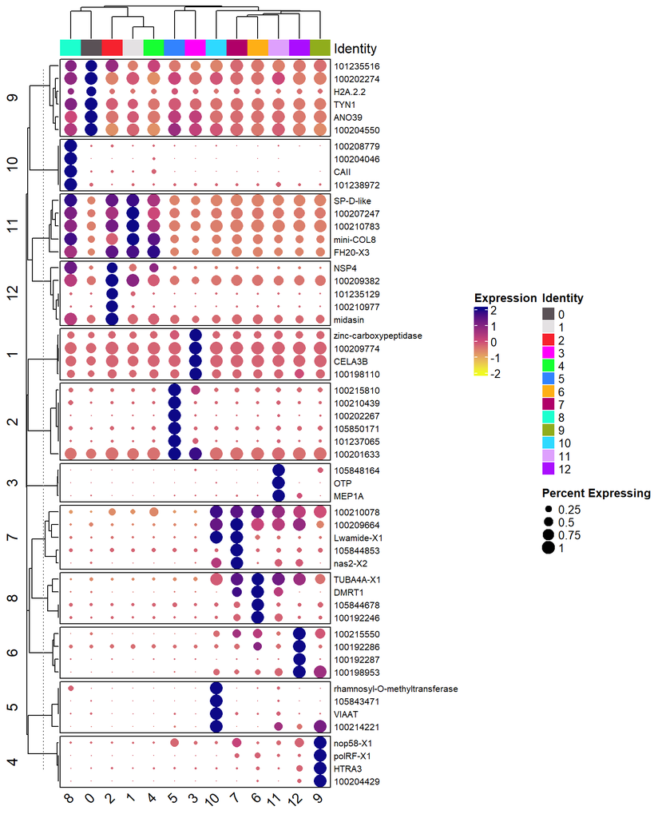

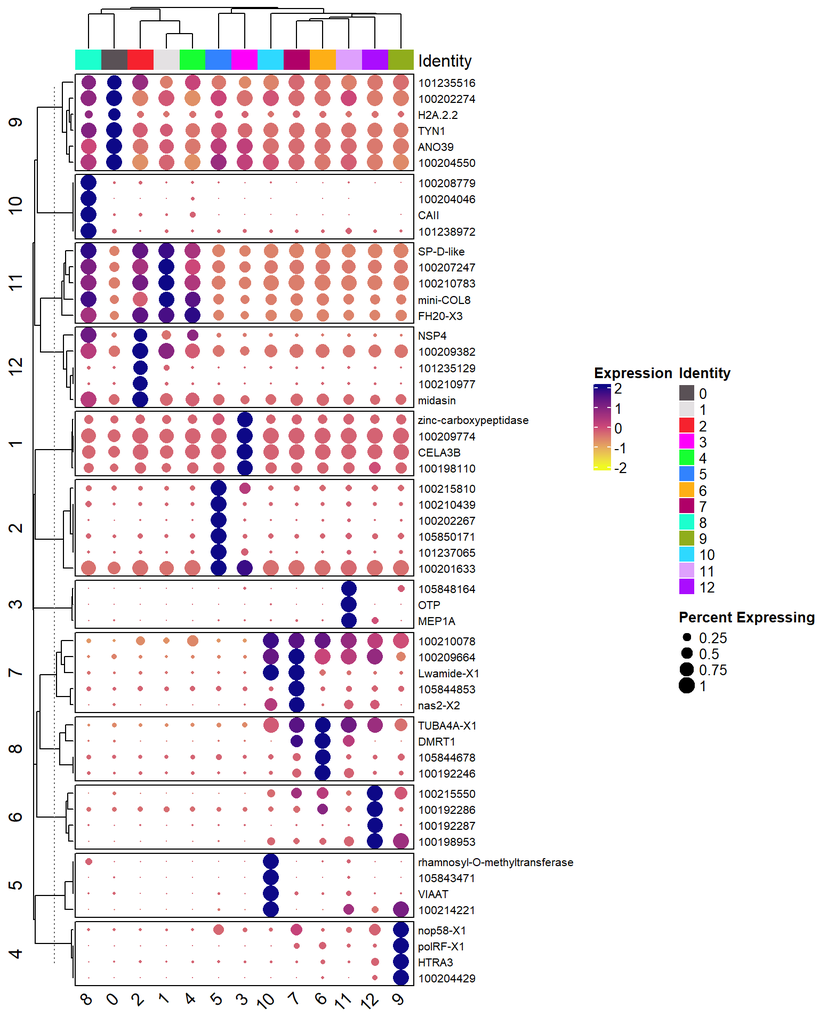

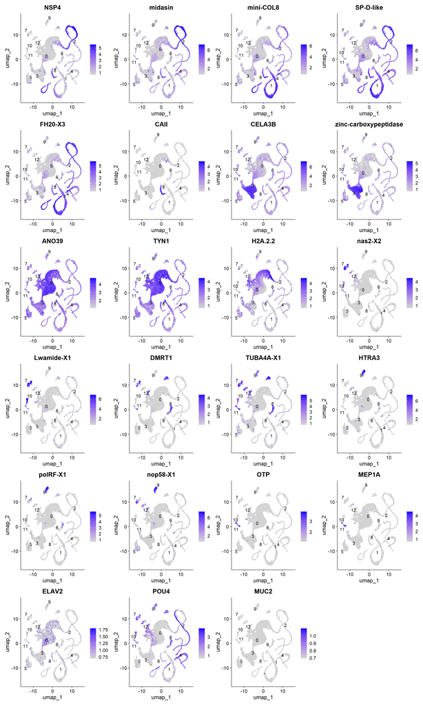